# Modern concepts and methods in Macroecology and Biogeography

Day 2: data.frames and GIS shapefiles in R; subsetting, joining & aggregating

Patrick Weigelt, Pierre Denelle & Holger Kreft

April 17th, 2024

*back to overview*

**Preparation:** Please open the RStudio project we established last week and download all data for the class from [Stud-IP](https://studip.uni-goettingen.de/dispatch.php/course/files/index/74501b33f332a6d238443bfbd502cc6c?cid=1746ae3fe971afbf90b74e3d64389586) (log in first) and unzip them into your project folder /data/. You can use `getwd()` to get your current working directory which is your project folder as long as you do not change it. Please install the following R-packages using `install.packages()` if not done yet:

- sf
- raster
- dplyr

If you want to visualize this tutorial in the viewer inside RStudio (to save space on your screen) run the following chunk of code:

```r
install.packages("rstudioapi") # install an R-package required for this step
dir <- tempfile()
dir.create(dir)
download.file("https://gift.uni-goettingen.de/mcmmb/index.html", destfile = file.path(dir, "index.html"))
download.file("https://gift.uni-goettingen.de/mcmmb/Day2.html", destfile = file.path(dir, "Day2.html"))
htmlFile <- file.path(dir, "Day2.html")
rstudioapi::viewer(htmlFile)
```

Now you can conveniently copy code from the viewer into your script.

## 1. Loading spreadsheet data into R

**Clean up**

```r
rm(list = ls()) # remove all objects first; alternatively press CTRL+SHIFT+F10 to also unmap loaded packages
```

**Load packages**

```r
library(dplyr)
```

As a start, we use functions from base R to organize our data. However, we load the `dplyr` package, a toolkit for splitting, applying and combining data. For more advanced and faster functions related to data manipulation, have a look at the documentation of the packages `dplyr`, `reshape2`, `data.table` etc.

**Load data**  
We use a version of `read.table()` to import data into R as a data.frame. Have a look at its help page.

```r
?read.table
```

```r
species <- read.csv("data/palms_species_per_gridcell.csv")
```

Here, we use data from [Kreft, H., Sommer, J.H. & Barthlott, W. (2006) The significance of geographic range size for spatial diversity patterns in Neotropical palms. *Ecography*, 29, 21-30](https://onlinelibrary.wiley.com/doi/full/10.1111/j.2005.0906-7590.04203.x).

**Inspection**

```r
dim(species)
```

```
## [1] 140860      4
```

```r
colnames(species) # rownames(species) for rows
```

```
## [1] "grid_id" "spp_Id"  "GENUS"   "EPITHET"
```

```r
str(species)
```

```
## 'data.frame':    140860 obs. of  4 variables:
##  $ grid_id: int  13735 13736 13737 13738 13910 13911 13912 13913 13914 14085 ...
##  $ spp_Id : int  550 550 550 550 550 550 550 550 550 550 ...
##  $ GENUS  : chr  "Ammandra" "Ammandra" "Ammandra" "Ammandra" ...
##  $ EPITHET: chr  "natalia" "natalia" "natalia" "natalia" ...
```

```r
class(species$GENUS)
```

```
## [1] "character"
```

```r
unique(species$GENUS) # or levels(species$GENUS)
```

```
##  [1] "Ammandra"        "Phytelephas"     "Geonoma"         "Asterogyne"
##  [5] "Calyptrogyne"    "Calyptronoma"    "Welfia"          "Pholidostachys"
##  [9] "Astrocaryum"     "Desmoncus"       "Bactris"         "Aiphanes"
## [13] "Gastrococcus"    "Acrocomia"       "Elaeis"          "Barcella"
## [17] "Attalea"         "Polyandrococcus" "Allagoptera"     "Parajubaea"
## [21] "Lytocaryum"      "Syagrus"         "Cocos"           "Jubaea"
## [25] "Butia"           "Roystonea"       "Hypospathe"      "Oenocarpus"
## [29] "Neonicholsonia"  "Prestoea"        "Euterpe"         "Reinhardtia"
## [33] "Leopoldinia"     "Manicaria"       "Wettinia"        "Socratea"
## [37] "Iriartea"        "Iriartella"      "Dictyocarpum"    "Wendlandiella"
## [41] "Chamaedorea"     "Synechanthus"    "Gaussia"         "Juania"
## [45] "Ceroxylon"       "Pseudophoenix"   "Lepidocaryum"    "Mauritiella"
## [49] "Mauritia"        "Raphia"          "Sabal"           "Washingtonia"
## [53] "Copernicia"      "Brahea"          "Serenoa"         "Acoelorraphe"
## [57] "Coplothrinax"    "Rhapidophyllum"  "Zombia"          "Coccothrinax"
## [61] "Thrinax"         "Schippia"        "Itaya"           "Crysophila"
## [65] "Chelyocarpus"    "Trithrinax"
```

**Adding a column to the data.frame**  
`paste()` allows us to combine both character strings of genus and epithet into a full species name.

```r
species$species <- paste(species$GENUS, species$EPITHET, sep = " ")
```

**Sorting**  
Click on the species object in the ‘Environment’ tab of RStudio or run `View(species)` to have a look at the table. Sorting in RStudio’s viewer does not change the order of the actual data. To sort the data.frame, use `order()`.

```r
order(species$grid_id)
```

Gives back the indices of grid_id in increasing order of the value of grid_id. They can be used to reorganize the data.frame accordingly.

```r
species <- species[order(species$grid_id), ]
```

## 2. Subsetting the data.frame using logical operators

*`which()` and operators: `==`, `>=`, `>`, `<`, `<=`, `%in%`, `is.na()`, `is.finite()`, `!`, `&`, `|`*

**Select unique subset for certain columns**

```r
species_unique <- unique(species[, c("spp_Id", "GENUS", "EPITHET", "species")])
# or: species_unique <- species[!duplicated(species$spp_Id),
# c("spp_Id", "GENUS", "EPITHET", "species")]

nrow(species_unique) # Number of species
```

```
## [1] 550
```

```r
length(unique(species$species))
```

```
## [1] 550
```

See how many species there are per genus

```r
spec_genera <- table(species_unique$GENUS) # contingency table of the counts of factor levels.
spec_genera
```

```
##
##    Acoelorraphe       Acrocomia        Aiphanes     Allagoptera        Ammandra
##               1               2              22               4               3
##      Asterogyne     Astrocaryum         Attalea         Bactris        Barcella
##               5              18              29              64               1
##          Brahea           Butia    Calyptrogyne    Calyptronoma       Ceroxylon
##               9               8               8               3              11
##     Chamaedorea    Chelyocarpus    Coccothrinax           Cocos      Copernicia
##              77               4              14               1              13
##    Coplothrinax      Crysophila       Desmoncus    Dictyocarpum          Elaeis
##               2               9               7               3               1
##         Euterpe    Gastrococcus         Gaussia         Geonoma      Hypospathe
##               7               1               5              51               3
##        Iriartea      Iriartella           Itaya          Juania          Jubaea
##               1               2               1               1               1
##     Leopoldinia    Lepidocaryum      Lytocaryum       Manicaria        Mauritia
##               3               1               2               1               2
##     Mauritiella  Neonicholsonia      Oenocarpus      Parajubaea  Pholidostachys
##               3               1               9               2               4
##     Phytelephas Polyandrococcus        Prestoea   Pseudophoenix          Raphia
##               6               1              11               4               1
##     Reinhardtia  Rhapidophyllum       Roystonea           Sabal        Schippia
##               6               1               9              16               1
##         Serenoa        Socratea         Syagrus    Synechanthus         Thrinax
##               1               5              30               2               7
##      Trithrinax    Washingtonia          Welfia   Wendlandiella        Wettinia
##               3               2               1               1              21
##          Zombia
##               1
```

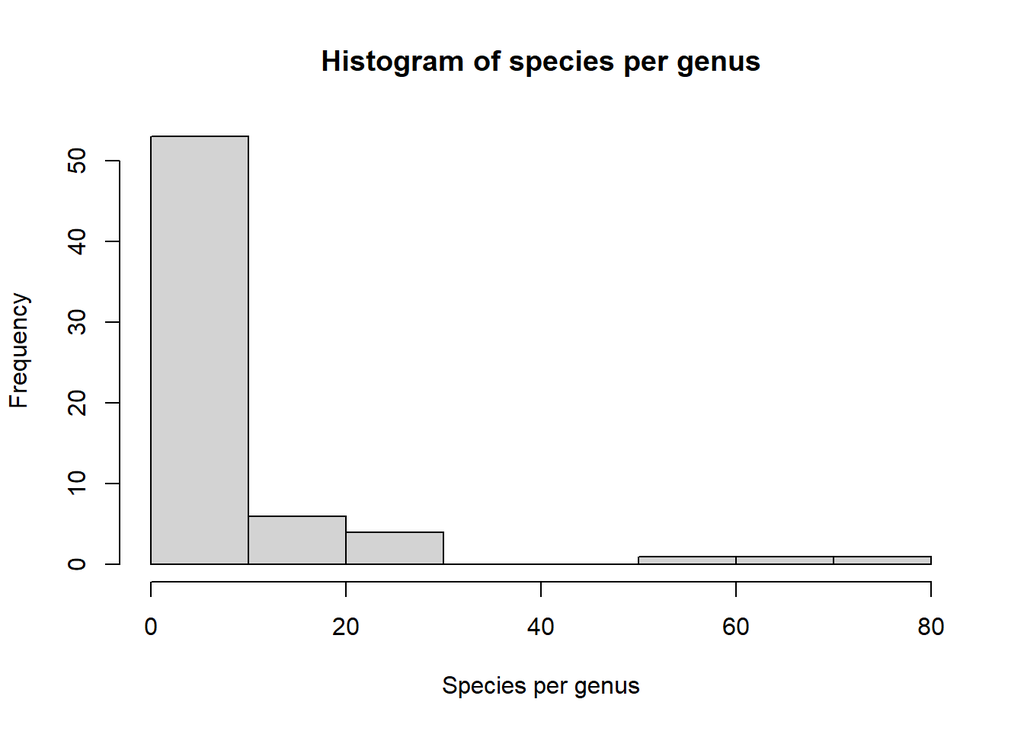

```r
# Histogram
hist(spec_genera, main = "Histogram of species per genus",
     xlab = "Species per genus")
```

**Choose entries of a given value**

```r
which(species$GENUS == "Ammandra") # index of all entries of genus "Ammandra"
```

```
##   [1]  22379  22445  23752  23806  25260  25295  25341  27108  27148  27208
##  [11]  29044  29085  29144  31100  31135  31175  33256  33309  35459  35515
##  [21]  45260  45314  47949  48005  48051  50699  50750  50795  50841  53536
##  [31]  59501  59558  59608  59654  62742  62798  62848  62894  62939  66028
##  [41]  66085  66134  66182  66230  66278  69349  69402  69451  69501  69553
##  [51]  69603  72659  72713  72760  72810  72864  72915  72967  75875  75926
##  [61]  75978  76022  76072  76123  76176  76230  76288  79050  79098  79144
##  [71]  79189  79239  79291  79344  79399  79458  79521  82051  82097  82140
##  [81]  82188  82240  82290  82341  82395  82456  82517  82580  84870  84917
##  [91]  84969  85026  85077  85129  85181  85238  85296  85355  85416  85477
## [101]  87587  87621  87677  87730  87780  87831  87887  87943  88001  88059
## [111]  88117  88173  90159  90215  90265  90314  90366  90420  90474  90530
## [121]  90588  90646  90702  90756  90803  92616  92672  92727  92778  92831
## [131]  92884  92937  92992  93050  93107  93163  93216  93263  93310  95064
## [141]  95119  95171  95222  95276  95328  95383  95438  95495  95552  95608
## [151]  95655  95702  97501  97556  97611  97664  97719  97773  97830  97888
## [161]  97942  97991  98039  98086  99915  99968 100021 100073 100127 100179
## [171] 100230 100278 100325 100373 100418 102313 102365 102416 102465 102513
## [181] 102559 102604
```

```r
head(species[which(species$GENUS == "Ammandra"), ]) # first six rows
```

```
##     grid_id spp_Id    GENUS    EPITHET             species
## 153   10937    549 Ammandra decasperma Ammandra decasperma
## 154   10938    549 Ammandra decasperma Ammandra decasperma
## 155   11112    549 Ammandra decasperma Ammandra decasperma
## 156   11113    549 Ammandra decasperma Ammandra decasperma
## 157   11286    549 Ammandra decasperma Ammandra decasperma
## 158   11287    549 Ammandra decasperma Ammandra decasperma
```

```r
# What species belong to this genus?
unique(species$species[which(species$GENUS == "Ammandra")])
```

```
## [1] "Ammandra decasperma" "Ammandra dasyneura"  "Ammandra natalia"
```

**OR**

```r
unique(species$species[which(species$GENUS == "Ammandra" | species$GENUS == "Washingtonia")]) # all species names in the genera "Ammandra" and "Washingtonia"
```

```
## [1] "Washingtonia filifera" "Washingtonia robusta"  "Ammandra decasperma"
## [4] "Ammandra dasyneura"    "Ammandra natalia"
```

```r
unique(species$species[which(species$GENUS %in% c("Ammandra", "Washingtonia"))])
```

```
## [1] "Washingtonia filifera" "Washingtonia robusta"  "Ammandra decasperma"
## [4] "Ammandra dasyneura"    "Ammandra natalia"
```

**AND**

```r
head(species[which(species$GENUS=="Ammandra" & species$EPITHET == "decasperma"), ]) # all entries of Ammandra decasperma
```

```
##     grid_id spp_Id    GENUS    EPITHET             species
## 153   10937    549 Ammandra decasperma Ammandra decasperma
## 154   10938    549 Ammandra decasperma Ammandra decasperma
## 155   11112    549 Ammandra decasperma Ammandra decasperma
## 156   11113    549 Ammandra decasperma Ammandra decasperma
## 157   11286    549 Ammandra decasperma Ammandra decasperma
## 158   11287    549 Ammandra decasperma Ammandra decasperma
```

```r
head(species[which(species$species == "Ammandra decasperma"), ])
```

```
##     grid_id spp_Id    GENUS    EPITHET             species
## 153   10937    549 Ammandra decasperma Ammandra decasperma
## 154   10938    549 Ammandra decasperma Ammandra decasperma
## 155   11112    549 Ammandra decasperma Ammandra decasperma
## 156   11113    549 Ammandra decasperma Ammandra decasperma
## 157   11286    549 Ammandra decasperma Ammandra decasperma
## 158   11287    549 Ammandra decasperma Ammandra decasperma
```

## 3. data.frame exercise

1. Make a subset of the data.frame that only includes entries for the 4 species *Geonoma pauciflora*, *Geonoma weberbaueri*, *Phytelephas tenuicaulis* & *Mauritia flexuosa*.
2. According to the [World Checklist of Vascular Plants](https://wcsp.science.kew.org/namedetail.do?name_id=89598), *Geonoma weberbaueri* is a synonym of *Geonoma undata*. Rename it!
3. In how many grid cells does each of these species occur?

## 4. GIS shapefiles in R

**Exercise: Have a look at the two shapefiles 30min_grid_select50%.shp and americas.shp in QGIS**

**Loading Geospatial R packages**

```r
install.packages("sf")
library(sf)
library(raster)
```

**Load spatial poylgons into R**

```r
grid <- st_read("data/30min_grid_select50/30min_grid_select50%.shp")
americas <- st_read("data/americas/americas.shp")
```

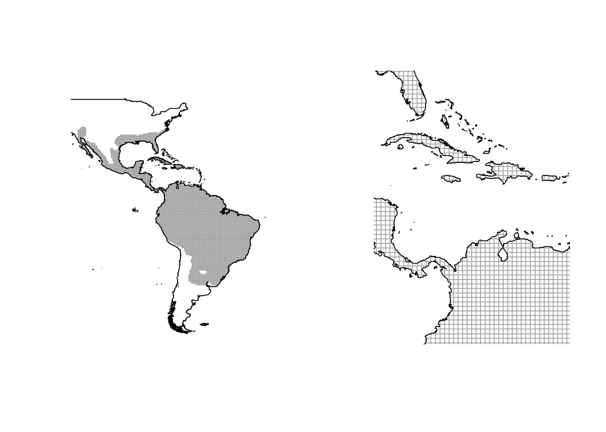

```r
# Plot
par(mfrow = c(1, 2))
plot(st_geometry(grid), border = "darkgrey")
plot(st_geometry(americas), add=TRUE)

plot(st_geometry(grid), border = "darkgrey", ylim = c(5, 25), xlim = c(-85, -65))
plot(st_geometry(americas), add = TRUE)
```

```r
class(grid)
```

```
## [1] "sf"         "data.frame"
```

```r
dim(grid)
```

```
## [1] 6038    4
```

```r
extent(grid)
```

```
## class      : Extent
## xmin       : -116.0007
## xmax       : -35.00066
## ymin       : -35
## ymax       : 36.5
```

**Projection**

```r
st_crs(grid)
```

```
## Coordinate Reference System: NA
```

not defined yet!

```r
st_crs(grid) <- "+proj=longlat +ellps=WGS84 +no_defs"
```

```r
st_crs(grid)
```

```
## Coordinate Reference System:
##   User input: +proj=longlat +ellps=WGS84 +no_defs
##   wkt:
## GEOGCRS["unknown",
##     DATUM["Unknown based on WGS 84 ellipsoid",
##         ELLIPSOID["WGS 84",6378137,298.257223563,
##             LENGTHUNIT["metre",1],
##             ID["EPSG",7030]]],
##     PRIMEM["Greenwich",0,
##         ANGLEUNIT["degree",0.0174532925199433],
##         ID["EPSG",8901]],
##     CS[ellipsoidal,2],
##         AXIS["longitude",east,
##             ORDER[1],
##             ANGLEUNIT["degree",0.0174532925199433,
##                 ID["EPSG",9122]]],
##         AXIS["latitude",north,
##             ORDER[2],
##             ANGLEUNIT["degree",0.0174532925199433,
##                 ID["EPSG",9122]]]]
```

```r
st_geometry(grid)
```

```
## Geometry set for 6038 features
## Geometry type: MULTIPOLYGON
## Dimension:     XY
## Bounding box:  xmin: -116.0007 ymin: -35 xmax: -35.00066 ymax: 36.5
## Geodetic CRS:  +proj=longlat +ellps=WGS84 +no_defs
## First 5 geometries:
```

```
## MULTIPOLYGON (((-114.0007 36, -114.5007 36, -11...
```

```
## MULTIPOLYGON (((-113.5007 36, -114.0007 36, -11...
```

```
## MULTIPOLYGON (((-113.0007 36, -113.5007 36, -11...
```

```
## MULTIPOLYGON (((-114.5007 35.5, -115.0007 35.5,...
```

```
## MULTIPOLYGON (((-114.0007 35.5, -114.5007 35.5,...
```

Check out http://proj4.org/ or http://epsg.io/ for spatial projections!

**Access the attribute table**

```r
head(grid)
```

```
## Simple feature collection with 6 features and 3 fields
## Geometry type: MULTIPOLYGON
## Dimension:     XY
## Bounding box:  xmin: -115.0007 ymin: 35.5 xmax: -113.0007 ymax: 36.5
## Geodetic CRS:  +proj=longlat +ellps=WGS84 +no_defs
##    ID AREA PORTION                       geometry
## 1 538 0.25     100 MULTIPOLYGON (((-114.0007 3...
## 2 539 0.25     100 MULTIPOLYGON (((-113.5007 3...
## 3 540 0.25     100 MULTIPOLYGON (((-113.0007 3...
## 4 712 0.25     100 MULTIPOLYGON (((-114.5007 3...
## 5 713 0.25     100 MULTIPOLYGON (((-114.0007 3...
## 6 714 0.25     100 MULTIPOLYGON (((-113.5007 3...
```

# 5. Joining and aggregating information

**Join species distributions to shapefile**

*Convert long table to species by grid-cell table*

```r
species <- species[, c("grid_id", "species")]
species_grid <- as.data.frame.matrix(table(species)) # Count species by gridcell combinations
species_grid[1:5, 1:5]
```

```
##     Acoelorraphe wrightii Acrocomia aculeata Acrocomia hassleri
## 538                     0                  0                  0
## 539                     0                  0                  0
## 540                     0                  0                  0
## 712                     0                  0                  0
## 713                     0                  0                  0
##     Aiphanes acaulis Aiphanes aculeata
## 538                0                 0
## 539                0                 0
## 540                0                 0
## 712                0                 0
## 713                0                 0
```

```r
species_grid <- data.frame(grid_id = as.integer(row.names(species_grid)), species_grid) # Add column with grid_id
species_grid[1:5, 1:5]
```

```
##     grid_id Acoelorraphe.wrightii Acrocomia.aculeata Acrocomia.hassleri
## 538     538                     0                  0                  0
## 539     539                     0                  0                  0
## 540     540                     0                  0                  0
## 712     712                     0                  0                  0
## 713     713                     0                  0                  0
##     Aiphanes.acaulis
## 538                0
## 539                0
## 540                0
## 712                0
## 713                0
```

```r
species_grid[which(species_grid$grid_id %in% c(5328:5332)), 1:4]
```

```
##      grid_id Acoelorraphe.wrightii Acrocomia.aculeata Acrocomia.hassleri
## 5328    5328                     1                  1                  0
## 5329    5329                     1                  1                  0
## 5330    5330                     1                  1                  0
## 5331    5331                     1                  1                  0
## 5332    5332                     1                  1                  0
```

*Join palm occurrences and spatial shapefile*

```r
names(grid)[1] <- "grid_id" #rename ID column to correspond to species_grid$grid_id
grid <- left_join(grid, species_grid, by = "grid_id") # Perform a "SQL" left join
grid[is.na(grid)] <- 0
grid[which(grid$grid_id %in% c(5328:5332)), 1:5]
```

```
## Simple feature collection with 5 features and 5 fields
## Geometry type: MULTIPOLYGON
## Dimension:     XY
## Bounding box:  xmin: -82.00066 ymin: 22.5 xmax: -79.50066 ymax: 23
## Geodetic CRS:  +proj=longlat +ellps=WGS84 +no_defs
##     grid_id    AREA PORTION Acoelorraphe.wrightii Acrocomia.aculeata
## 558    5328 0.19638  78.552                     1                  1
## 559    5329 0.25000 100.000                     1                  1
## 560    5330 0.24921  99.684                     1                  1
## 561    5331 0.22011  88.044                     1                  1
## 562    5332 0.13200  52.800                     1                  1
##                           geometry
## 558 MULTIPOLYGON (((-81.50066 2...
## 559 MULTIPOLYGON (((-81.00066 2...
## 560 MULTIPOLYGON (((-80.50066 2...
## 561 MULTIPOLYGON (((-80.3008 23...
## 562 MULTIPOLYGON (((-79.93695 2...
```

**Make distribution maps for the four species**

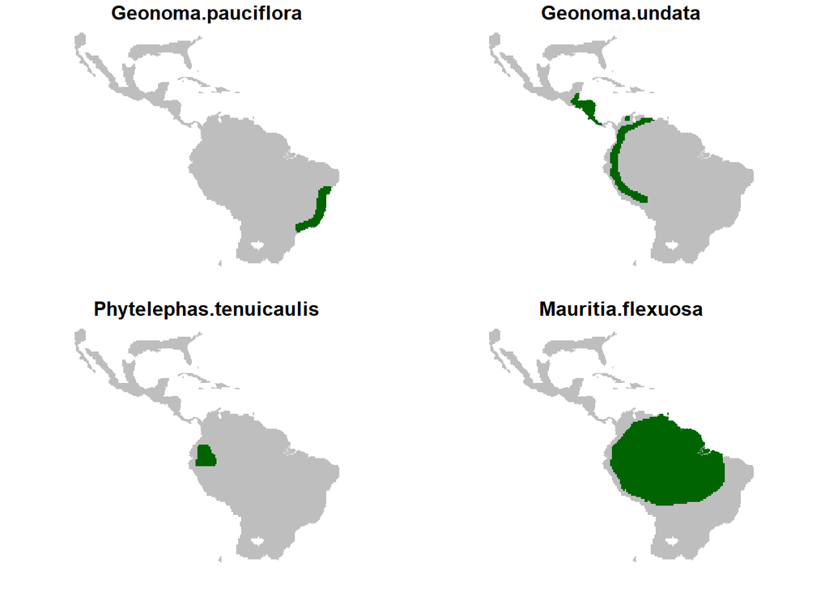

```r
plot(grid[c("Geonoma.pauciflora", "Geonoma.undata", "Phytelephas.tenuicaulis", "Mauritia.flexuosa")], border = NA, pal=c("grey","darkgreen"))
```

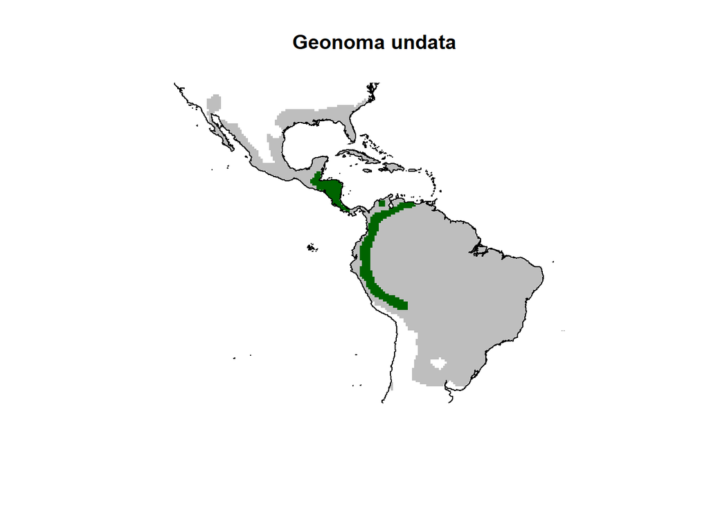

```r
plot(st_geometry(grid), col=ifelse(grid$Geonoma.undata==1,"darkgreen","grey"), border=NA, main="Geonoma undata")
plot(st_geometry(americas), add=TRUE)
```

To go further, you can have a look at this nice tutorials: http://edrub.in/ARE212/section12.html, https://r-spatial.github.io/sf/articles/sf5.html